# Session 1 Solutions

# Identifying the input files

The sequencing reads were quantified using the salmon tool (out of the scope of this course). The output of this tool is kept in the `salmon_quant` directory of the course data folder.

We have to use the `list.files` function to locate all the files. It can be run in “recursive” mode means that it checks all sub-folders.

```r
## see help for list.files
## recursive checks all sub-folders
## full.names returns the path in addition to the file name

## dirs contain all the sample names
dirs <- list.files("salmon_quant/")
quant_files <- list.files("salmon_quant/",pattern="quant.sf.gz",recursive = TRUE,full.names = TRUE)

## Set nicer names
names(quant_files) <- dirs
quant_files
```

```
                             1_CTR_BC_2
 "salmon_quant//1_CTR_BC_2/quant.sf.gz"
                             2_TGF_BC_4
 "salmon_quant//2_TGF_BC_4/quant.sf.gz"
                              3_IR_BC_5
  "salmon_quant//3_IR_BC_5/quant.sf.gz"
                             4_CTR_BC_6
 "salmon_quant//4_CTR_BC_6/quant.sf.gz"
                             5_TGF_BC_7
 "salmon_quant//5_TGF_BC_7/quant.sf.gz"
                             6_IR_BC_12
 "salmon_quant//6_IR_BC_12/quant.sf.gz"
                            7_CTR_BC_13
"salmon_quant//7_CTR_BC_13/quant.sf.gz"
                            8_TGF_BC_14
"salmon_quant//8_TGF_BC_14/quant.sf.gz"
                             9_IR_BC_15
 "salmon_quant//9_IR_BC_15/quant.sf.gz"
```

# Importing the files

Two further files are required. 1) the transcript to gene mapping (created previously to save time). 2) the sample information

```r
library(readr)
tx2gene <- read_csv("tx2gene.csv")
sampleinfo <- read.csv("meta_data/sampleInfo.csv")
```

The `tximport` package is first required to import the quantification files, and summarise them to the gene level.

```r
library(tximport)

# ignoreTxVersion is required to make sure the transcript names match up

txi <- tximport(quant_files,type="salmon",tx2gene = tx2gene,ignoreTxVersion = TRUE)
```

```
reading in files with read_tsv
1 2 3 4 5 6 7 8 9
transcripts missing from tx2gene: 1
summarizing abundance
summarizing counts
summarizing length
```

We can now read these data into `DESeq2`. It has many possible input formats each of which requires a different function. One of the arguments is a data frame containing sample information. The design specifies which contrast we want to analyse in R’s modeling format (using the `~` symbol). In the simplest case the design argument can correspond to a column in the sample information that we want to compare.

```r
library(DESeq2)
dds <- DESeqDataSetFromTximport(txi,
                                colData = sampleinfo,
                                design = ~condition)
```

```
some variables in design formula are characters, converting to factors
```

```r
dds
```

```
class: DESeqDataSet
dim: 57914 9
metadata(1): version
assays(2): counts avgTxLength
rownames(57914): ENSG00000000003 ENSG00000000005 ...
  ENSG00000284747 ENSG00000284748
rowData names(0):
colnames(9): 1_CTR_BC_2 2_TGF_BC_4 ... 8_TGF_BC_14 9_IR_BC_15
colData names(5): Run condition Name Replicate Treated
```

It is useful to check the number of reads obtained for each sample. Low read count could indicate technical issues such as poor RNA quality. The number of reads for each sample can be obtained by summing each column in the `assay(dds)` data frame. These can be plotted as a bar graph.

```r
library(dplyr)
library(ggplot2)
png("images/lib_size.png")
mutate(sampleinfo, LibSize = colSums(assay(dds))/1e6) %>%
  ggplot(aes(x = Name, y = LibSize)) + geom_col(fill="steelblue") + geom_hline(yintercept = 20,col="red",lty=2)
```

# PCA exercise

Colouring by `condition` reveals some inconsistencies in encoding

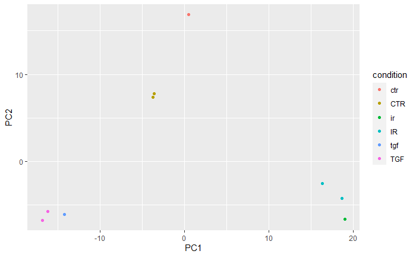

```r
library(dplyr)
library(ggplot2)
pca_data <- plotPCA(vsd,intgroup="Treated",returnData = TRUE) %>%
  dplyr::rename(Run = name) %>%
  left_join(sampleinfo)
  ggplot(pca_data,aes(x = PC1, y = PC2,col=condition)) + geom_point()
```

Adding labels to the plot with `geom_text`

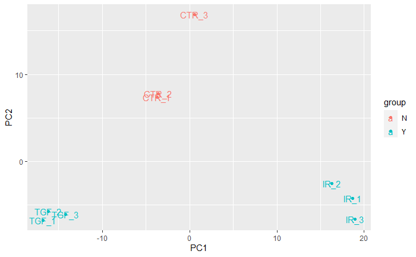

Nicer positioning of the labels is possible with the `ggrepel` package.

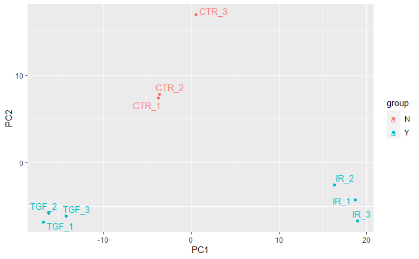

```r
library(ggrepel)
pca_data <- plotPCA(vsd,intgroup="Treated",returnData = TRUE) %>%
  dplyr::rename(Run = name) %>%
  left_join(sampleinfo)
  ggplot(pca_data,aes(x = PC1, y = PC2,col=group,label = Name)) + geom_point() + geom_text_repel()
```

# Repeat analysis with new sample sheet

```r
sampleinfo_corrected <- read_tsv("meta_data/sampleInfo_corrected.txt")
dds <- DESeqDataSetFromTximport(txi,
                                colData = sampleinfo_corrected,
                                design = ~condition)
```

```
some variables in design formula are characters, converting to factorsusing counts and average transcript lengths from tximport
```

```r
dds
```

```
class: DESeqDataSet
dim: 57914 9
metadata(1): version
assays(2): counts avgTxLength
rownames(57914): ENSG00000000003 ENSG00000000005 ...
  ENSG00000284747 ENSG00000284748
rowData names(0):
colnames(9): 1_CTR_BC_2 2_TGF_BC_4 ... 8_TGF_BC_14 9_IR_BC_15
colData names(5): Run condition Name Replicate Treated
```

## Verify sample groups are correct

```r
vsd <- vst(dds)
```

```
using 'avgTxLength' from assays(dds), correcting for library size
```

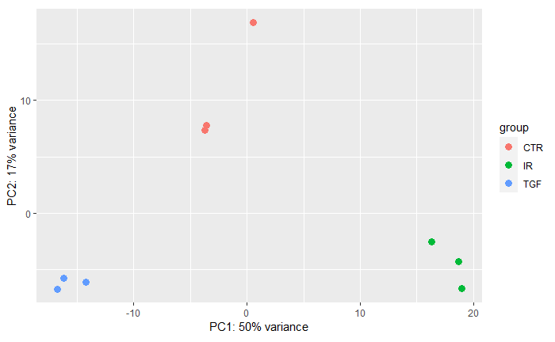

```r
plotPCA(vsd,intgroup="condition")
```